# Insertions and deletions in the great tit genome

01/05/18

## Introduction

## Insertions and deletions

- short INDELs: sections of DNA < 50bp that are deleted or inserted in a genome
- deletion bias in most organisms
- deletions more deleterious than insertions

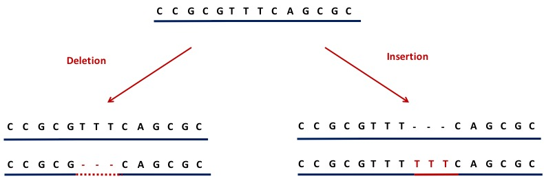

## INDELs often overlooked

- Disproportionately occur in repetitive sequence
- Hard to align
- Often occur in hotspots
- 1/8 as frequent as SNPs in humans

(Earl et al., 2014; Montgomery et al., 2013)

## The importance of INDELs in genome evolution

- Influence genome size:
  - low deletion rate \(\rightarrow\) large genomes?
  - high deletion rate \(\rightarrow\) compact genomes?
  - selection on insertions to maintain minimum intron size?
- Contribute more to sequence divergence, in terms of the number of base differences, than SNPs

(Britten, 2002; Leushkin and Bazykin, 2013; Nam and Ellegren, 2012; Ometto et al., 2005; Sun et al., 2012)

## INDEL mutation

- Deletion bias in most organisms
- Polymerase slippage can explain majority of short INDEL events

## INDEL selection

- Deletions
  - lower mean allele frequency
  - more deleterious
  - two breakpoints
- Insertions may be favoured:
  - elevated fixation probability
  - biased gene conversion
  - minimum intron size
  - polarisation error

## Importance of polarisation error

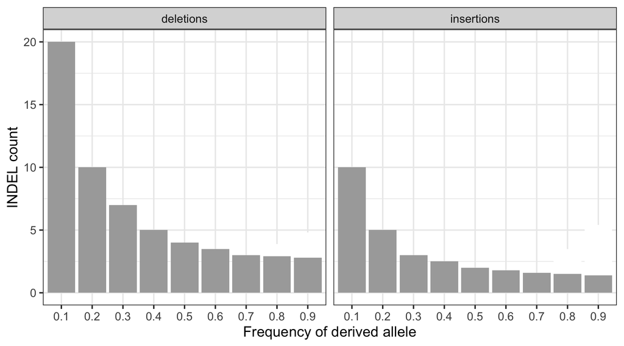

(see Hernandez et al., 2007)

## Importance of polarisation error

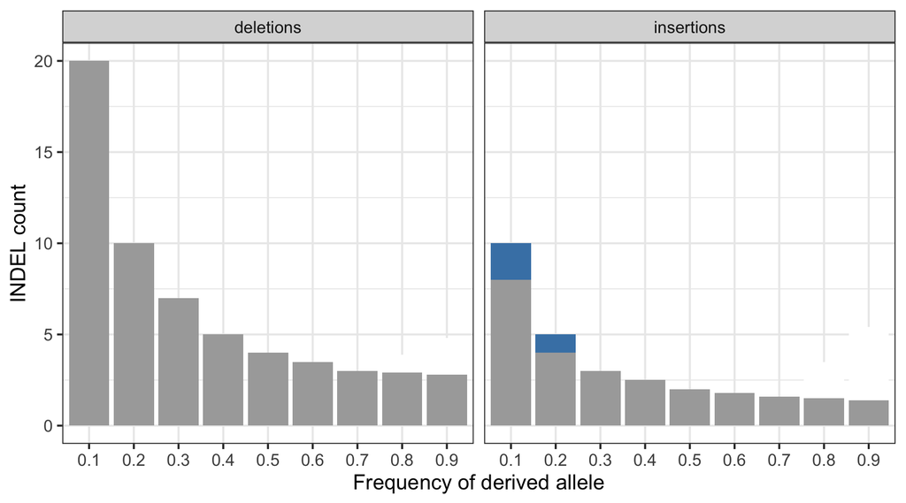

(see Hernandez et al., 2007)

## Importance of polarisation error

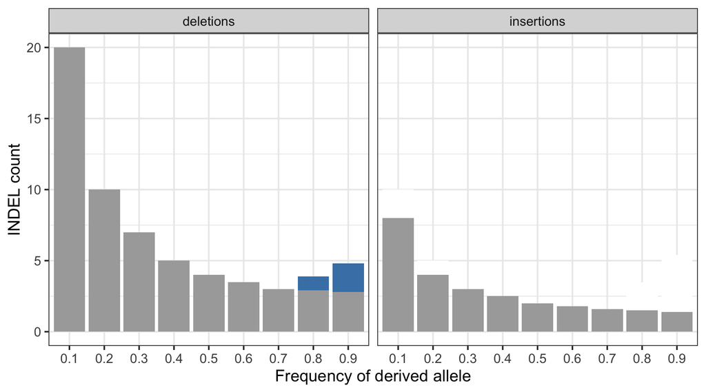

(see Hernandez et al., 2007)

## Importance of polarisation error

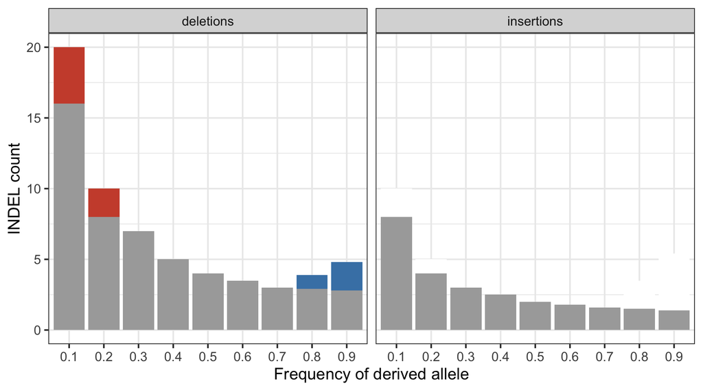

(see Hernandez et al., 2007)

## Importance of polarisation error

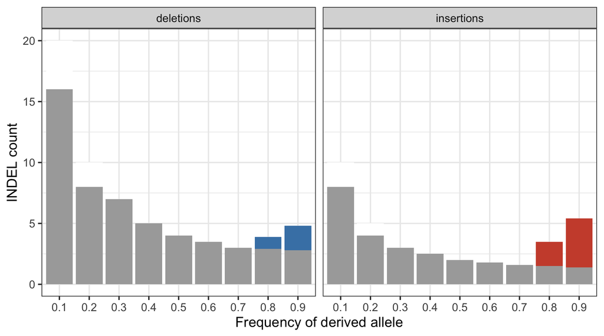

(see Hernandez et al., 2007)

## Importance of polarisation error

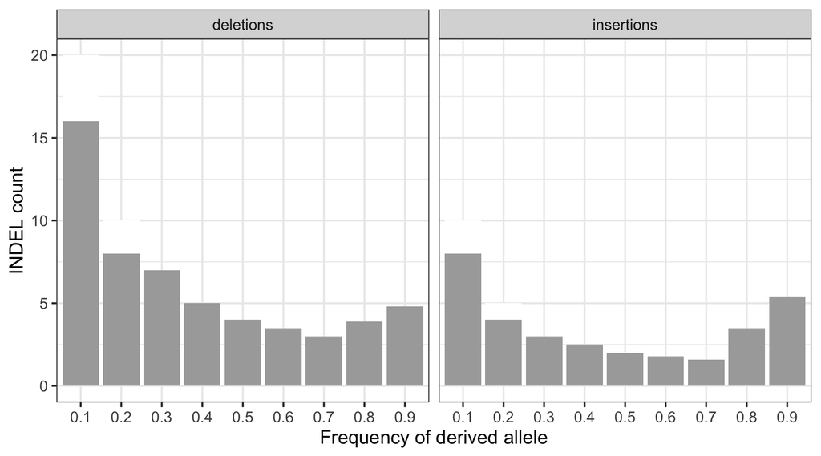

(see Hernandez et al., 2007)

## Aims

Quanitfy how natural selection shapes INDEL diversity in the great tit (*Parus major*)

1. within coding regions
2. in non-coding regions

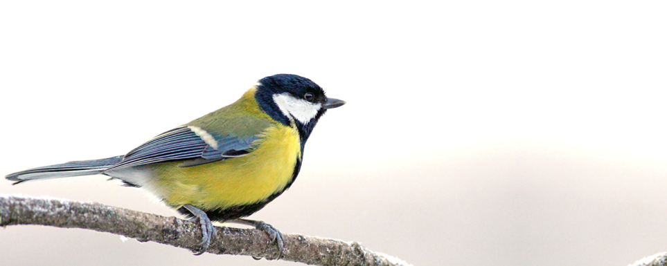

## Advantages of an avian system

- Conserved karyotype and synteny - good for alignments
- Genomes consist of few large macrochromosomes and many small microchromosomes
- Results in a highly dynamic recombination landscape - power to associations with recombination

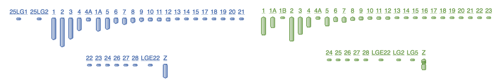

(van Oers et al., 2014; Stapley et al., 2008)

## Data

## Sample and pipeline

- 10 european great tit males (Corcoran et al., 2017)
- high coverage (44x)
- variant calling with GATK
- multispecies alignment between zebra finch, flycatcher and great tit
- parsimony based polarisation

[figure not shown]

## The model - 'anavar'

## A novel maximum likelihood approach

- takes the unfolded site frequency spectrum
- estimates for both insertions and deletions:
  - mutation rate (\(\theta = 4N_e\mu\))
  - selection:
    - either selection coefficient (\(\gamma = 4N_es\))
    - or scale and shape paramater for distribution of fitness effects
  - polarisation error
- Controls for demography using neutral sites (Eyre-Walker et al., 2006)

(Barton and Zeng, 2018)

## Dataset summary

## Regional variation in purifying selection

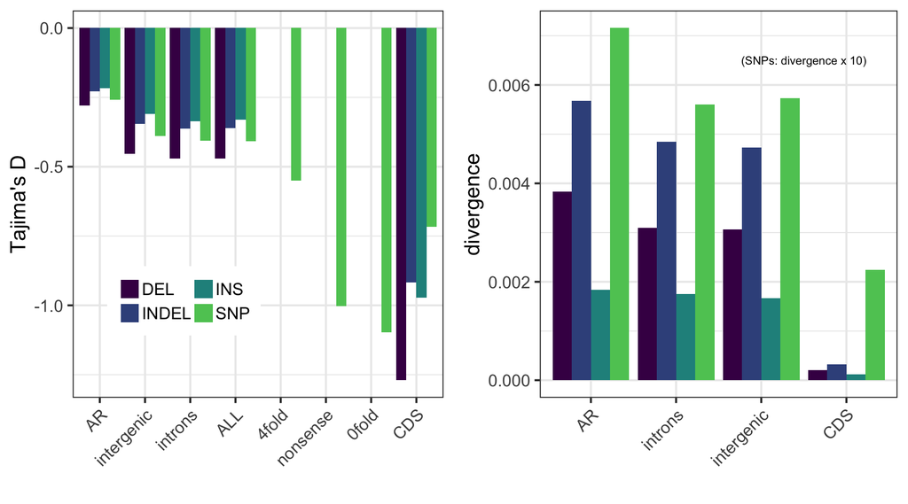

## Coding INDELs

## INDELs predominantly strongly deleterious

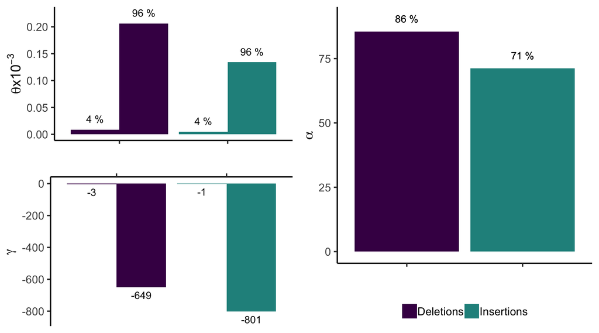

## Moving away from coding regions

## Approach

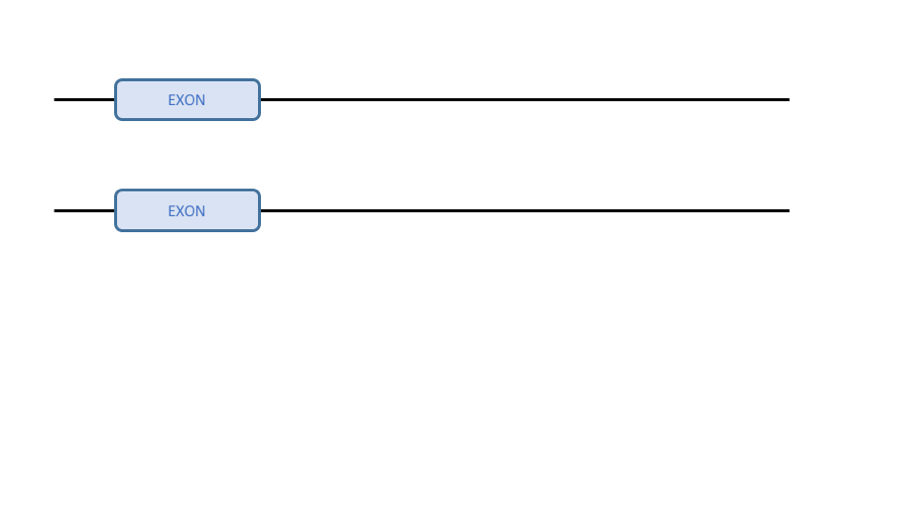

## Approach

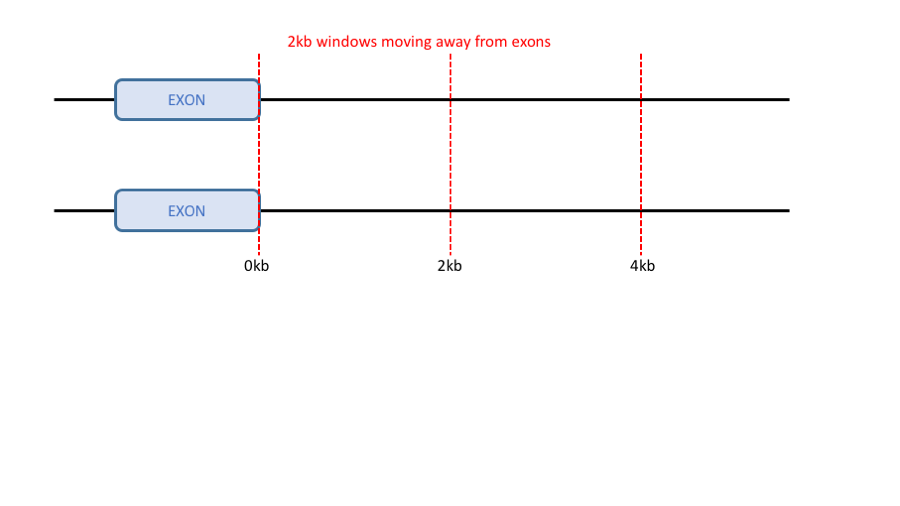

## Approach

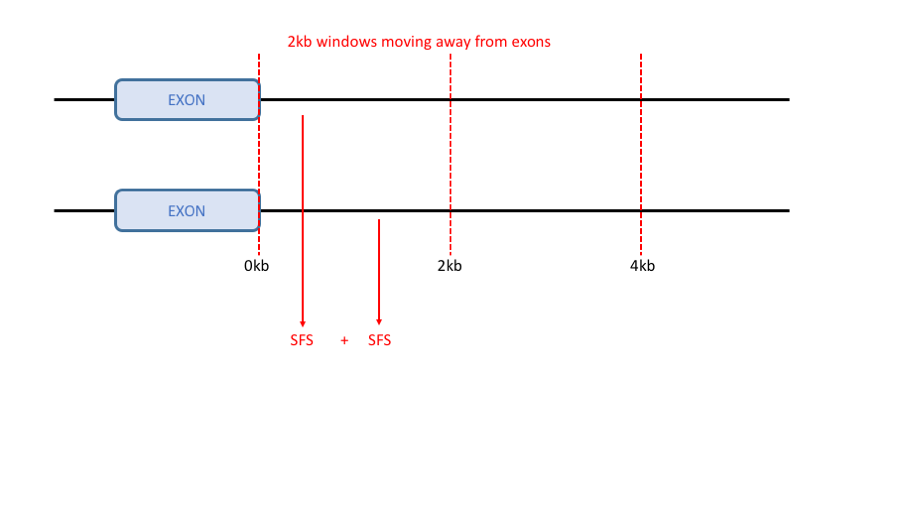

## Approach

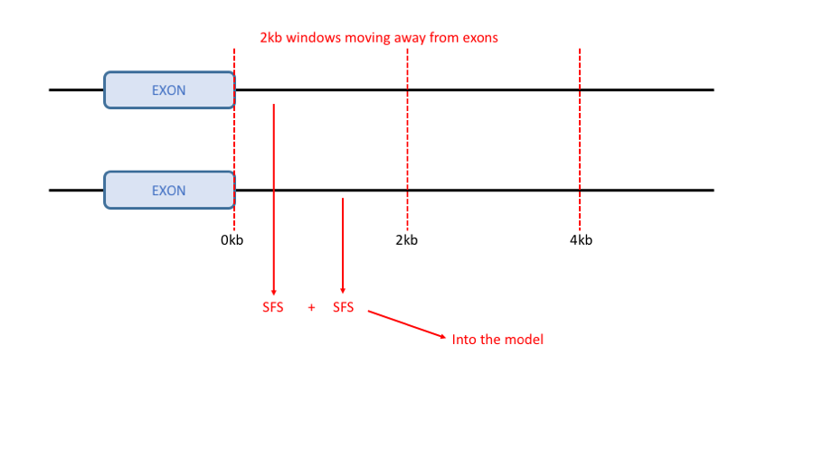

## Evidence for linked selection

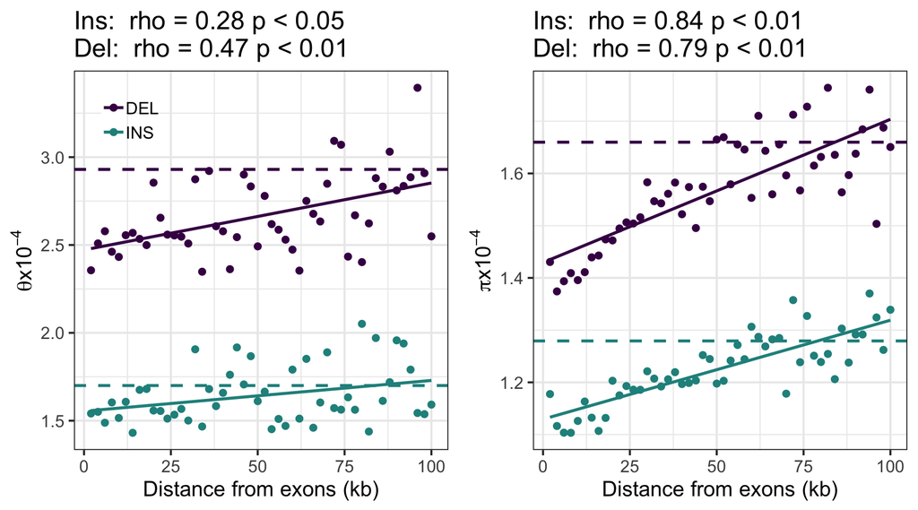

## Recombination Analyses

## Getting the data

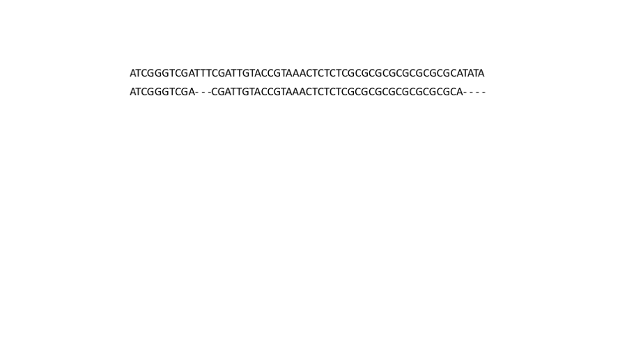

## Getting the data

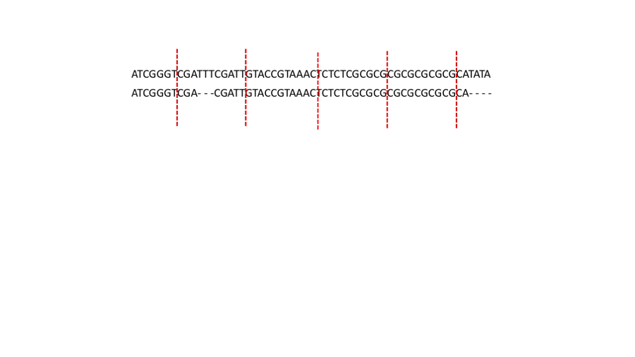

## Getting the data

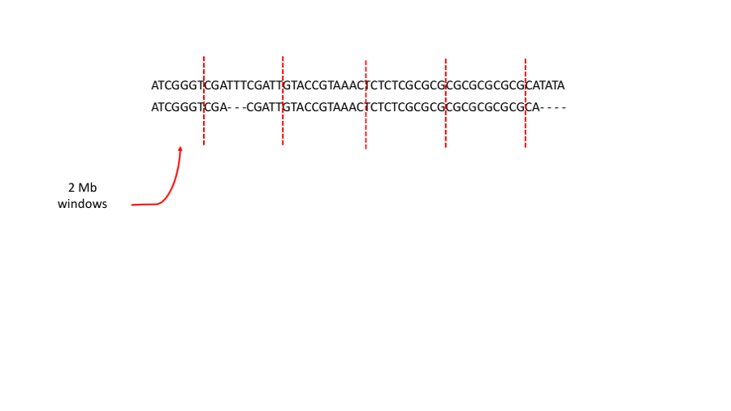

## Getting the data

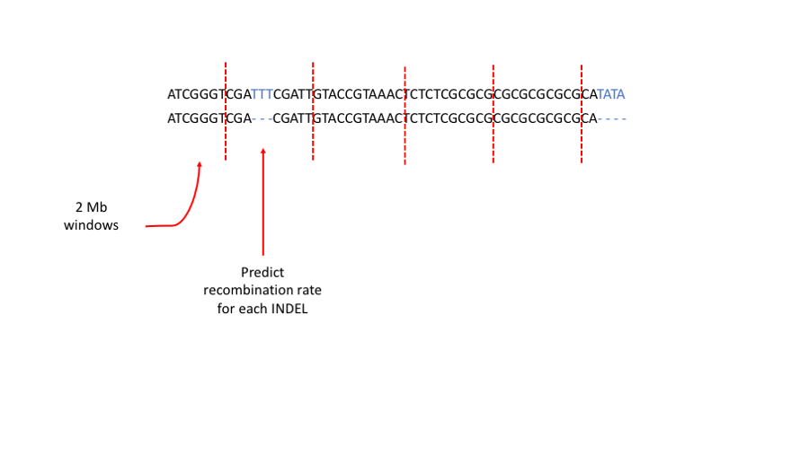

## Getting the data - recombination rate

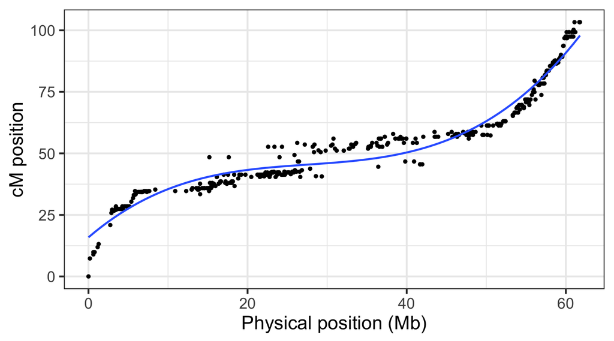

## Getting the data

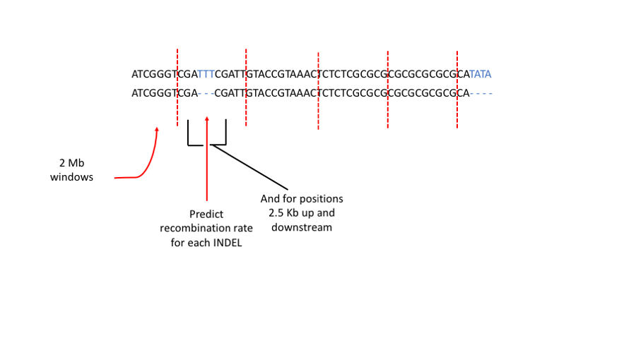

## Getting the data

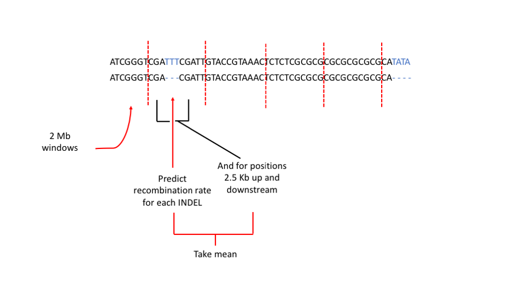

## Getting the data

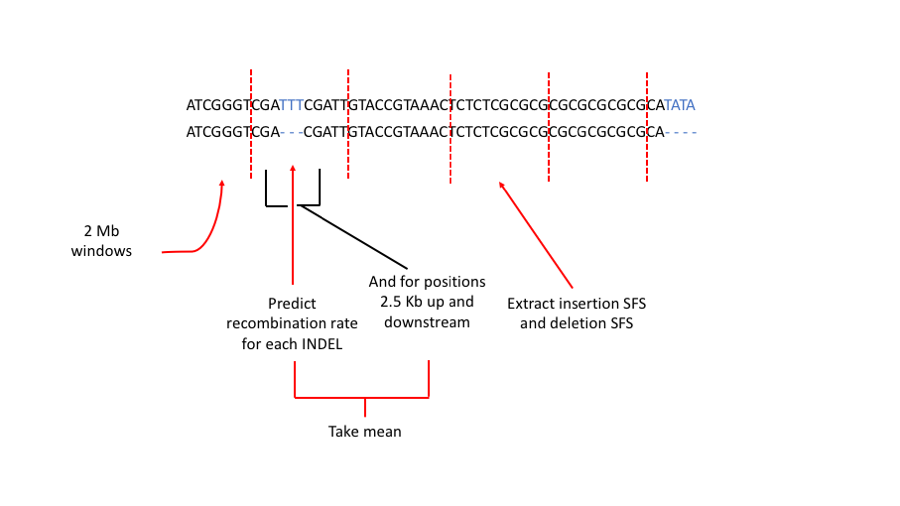

## Getting the data

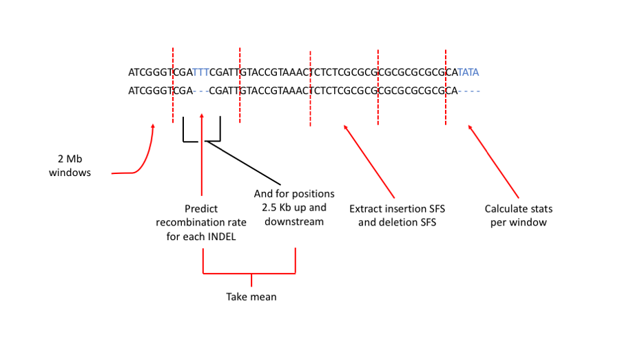

## Association between diversity and recombination

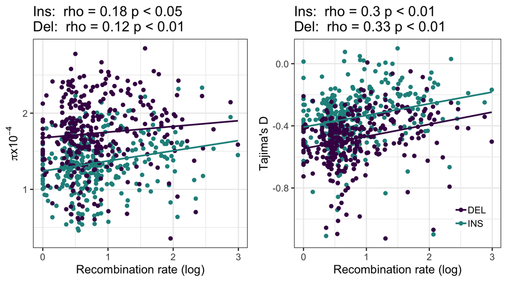

## Round up

## Conclusion

- INDELs in genes are bad
- Don't find a link between recombination rate and deletion bias
- Linked selection appears to be constraining INDEL rates

## Next steps

- Calculate alpha - proportion of substitutions fixed by positive selection
- Separate UCNE and CDS in linked selection analysis
- Any suggestions?